# Spotify Analysis

Antonio Marks

10/10/2018

```r
load("data/token.rda")

Sys.setenv(SPOTIFY_CLIENT_ID = client)
Sys.setenv(SPOTIFY_CLIENT_SECRET = secret)
access_token <- get_spotify_access_token()
# get_spotify_authorization_code()
```

## Analysis of how music tastes has changed

Notes: 1. Make sure you locally store your client id and client secret so you don’t share them with others. 2. Since you’re not pulling data from your our account but rather public data, the spotifyr package should work, i.e. we’re not going to have the problems we had before. 3. More information about the package and how to create your spotify API access [here](https://github.com/charlie86/spotifyr).

## Data

The data collected shows all types of information , such as:

- *Danceability*
- *Release Date Info*
- *Popularity*
- *Etc.*

For Example, the information for the artist Drake is shown below and was pulled using the Spotifyr package.

| artist_name | artist_uri | album_uri | album_name | album_img | album_type | is_collaboration | album_release_date | album_release_year | album_popularity | track_name | track_uri | track_number | disc_number | danceability | energy | key | loudness | mode | speechiness | acousticness | instrumentalness | liveness | valence | tempo | duration_ms | time_signature | key_mode | track_popularity | track_preview_url | … |
| --- | --- | --- | --- | --- | --- | --- | --- | --- | --- | --- | --- | --- | --- | --- | --- | --- | --- | --- | --- | --- | --- | --- | --- | --- | --- | --- | --- | --- | --- | --- |
| Drake | 3TVXtAsR1Inumwj472S9r4 | 1ATL5GLyefJaxhQzSPVrLX | Scorpion | https://i.scdn.co/image/542d705154be4049fc927050d006987e63739bbd | album | FALSE | 2018-06-29 | 2018-06-29 | 100 | Survival | 2yg9UN4eo5eMVJ7OB4RWj3 | 1 | 1 | 0.607 | 0.596 | A | -9.090 | minor | 0.3580 | 0.13300 | 0.00e+00 | 0.1230 | 0.1490 | 77.324 | 136187 | 4 | A minor | 77 | NA | … |
| Drake | 3TVXtAsR1Inumwj472S9r4 | 1ATL5GLyefJaxhQzSPVrLX | Scorpion | https://i.scdn.co/image/542d705154be4049fc927050d006987e63739bbd | album | FALSE | 2018-06-29 | 2018-06-29 | 100 | Nonstop | 0TlLq3lA83rQOYtrqBqSct | 2 | 1 | 0.912 | 0.412 | G | -8.074 | major | 0.1240 | 0.01640 | 1.30e-02 | 0.1040 | 0.4220 | 154.983 | 238614 | 4 | G major | 94 | NA | … |
| Drake | 3TVXtAsR1Inumwj472S9r4 | 1ATL5GLyefJaxhQzSPVrLX | Scorpion | https://i.scdn.co/image/542d705154be4049fc927050d006987e63739bbd | album | FALSE | 2018-06-29 | 2018-06-29 | 100 | Elevate | 3szf2z1Cy1QMrtHrbn8rz9 | 3 | 1 | 0.758 | 0.474 | C# | -8.720 | major | 0.1460 | 0.01500 | 0.00e+00 | 0.1160 | 0.0541 | 76.062 | 184960 | 4 | C# major | 80 | NA | … |
| Drake | 3TVXtAsR1Inumwj472S9r4 | 1ATL5GLyefJaxhQzSPVrLX | Scorpion | https://i.scdn.co/image/542d705154be4049fc927050d006987e63739bbd | album | FALSE | 2018-06-29 | 2018-06-29 | 100 | Emotionless | 5Psnhdkyanjpgc2P8A5TSM | 4 | 1 | 0.413 | 0.677 | C# | -5.120 | major | 0.2550 | 0.02490 | 0.00e+00 | 0.0793 | 0.0845 | 172.501 | 302173 | 4 | C# major | 80 | NA | … |
| Drake | 3TVXtAsR1Inumwj472S9r4 | 1ATL5GLyefJaxhQzSPVrLX | Scorpion | https://i.scdn.co/image/542d705154be4049fc927050d006987e63739bbd | album | FALSE | 2018-06-29 | 2018-06-29 | 100 | God’s Plan | 6DCZcSspjsKoFjzjrWoCdn | 5 | 1 | 0.754 | 0.449 | G | -9.211 | major | 0.1090 | 0.03320 | 8.29e-05 | 0.5520 | 0.3570 | 77.169 | 198973 | 4 | G major | 93 | NA | … |
| Drake | 3TVXtAsR1Inumwj472S9r4 | 1ATL5GLyefJaxhQzSPVrLX | Scorpion | https://i.scdn.co/image/542d705154be4049fc927050d006987e63739bbd | album | FALSE | 2018-06-29 | 2018-06-29 | 100 | I’m Upset | 3qN5qMTKyEEmiTZD38BNTT | 6 | 1 | 0.899 | 0.586 | B | -7.866 | minor | 0.3440 | 0.27900 | 0.00e+00 | 0.0836 | 0.4920 | 150.001 | 214467 | 4 | B minor | 86 | NA | … |
| Drake | 3TVXtAsR1Inumwj472S9r4 | 1ATL5GLyefJaxhQzSPVrLX | Scorpion | https://i.scdn.co/image/542d705154be4049fc927050d006987e63739bbd | album | FALSE | 2018-06-29 | 2018-06-29 | 100 | 8 Out Of 10 | 0zqy3ss4CwD6u4QPksS0nI | 7 | 1 | 0.529 | 0.690 | D | -7.870 | major | 0.7400 | 0.16100 | 0.00e+00 | 0.4980 | 0.3110 | 170.540 | 195720 | 4 | D major | 77 | NA | … |
| Drake | 3TVXtAsR1Inumwj472S9r4 | 1ATL5GLyefJaxhQzSPVrLX | Scorpion | https://i.scdn.co/image/542d705154be4049fc927050d006987e63739bbd | album | FALSE | 2018-06-29 | 2018-06-29 | 100 | Mob Ties | 7rC5Pl8rQSX4myONQHYPBK | 8 | 1 | 0.755 | 0.575 | E | -8.393 | minor | 0.0678 | 0.04560 | 1.24e-03 | 0.2760 | 0.4900 | 85.987 | 205147 | 4 | E minor | 86 | NA | … |
| Drake | 3TVXtAsR1Inumwj472S9r4 | 1ATL5GLyefJaxhQzSPVrLX | Scorpion | https://i.scdn.co/image/542d705154be4049fc927050d006987e63739bbd | album | FALSE | 2018-06-29 | 2018-06-29 | 100 | Can’t Take A Joke | 1dUHF4RyMmMTveJ0Rby6Xm | 9 | 1 | 0.761 | 0.598 | A# | -7.249 | minor | 0.1820 | 0.12800 | 0.00e+00 | 0.0839 | 0.4470 | 173.897 | 163974 | 4 | A# minor | 81 | NA | … |
| Drake | 3TVXtAsR1Inumwj472S9r4 | 1ATL5GLyefJaxhQzSPVrLX | Scorpion | https://i.scdn.co/image/542d705154be4049fc927050d006987e63739bbd | album | FALSE | 2018-06-29 | 2018-06-29 | 100 | Sandra’s Rose | 6cblRiEGDRNZgowcm951R3 | 10 | 1 | 0.487 | 0.849 | C# | -5.432 | major | 0.2460 | 0.04810 | 0.00e+00 | 0.1430 | 0.5200 | 152.093 | 216333 | 4 | C# major | 76 | NA | … |
| Drake | 3TVXtAsR1Inumwj472S9r4 | 1ATL5GLyefJaxhQzSPVrLX | Scorpion | https://i.scdn.co/image/542d705154be4049fc927050d006987e63739bbd | album | FALSE | 2018-06-29 | 2018-06-29 | 100 | Talk Up (feat. Jay-Z) | 4ksuI04WMvUnJbHQjgs3L5 | 11 | 1 | 0.758 | 0.490 | B | -9.877 | major | 0.1390 | 0.00359 | 6.60e-06 | 0.2920 | 0.3350 | 140.116 | 223240 | 4 | B major | 77 | NA | … |
| Drake | 3TVXtAsR1Inumwj472S9r4 | 1ATL5GLyefJaxhQzSPVrLX | Scorpion | https://i.scdn.co/image/542d705154be4049fc927050d006987e63739bbd | album | FALSE | 2018-06-29 | 2018-06-29 | 100 | Is There More | 1Tnw0ItH1Macok8gblnPPd | 12 | 1 | 0.698 | 0.547 | C# | -7.607 | major | 0.3150 | 0.72700 | 0.00e+00 | 0.1590 | 0.5480 | 83.801 | 226907 | 4 | C# major | 74 | NA | … |
| Drake | 3TVXtAsR1Inumwj472S9r4 | 1ATL5GLyefJaxhQzSPVrLX | Scorpion | https://i.scdn.co/image/542d705154be4049fc927050d006987e63739bbd | album | FALSE | 2018-06-29 | 2018-06-29 | 100 | Peak | 11L064movtyopGdLiX4sVg | 1 | 2 | 0.686 | 0.215 | A | -13.540 | minor | 0.0387 | 0.85000 | 1.23e-04 | 0.1060 | 0.2730 | 91.998 | 206027 | 4 | A minor | 75 | NA | … |
| Drake | 3TVXtAsR1Inumwj472S9r4 | 1ATL5GLyefJaxhQzSPVrLX | Scorpion | https://i.scdn.co/image/542d705154be4049fc927050d006987e63739bbd | album | FALSE | 2018-06-29 | 2018-06-29 | 100 | Summer Games | 4HG1YiGBseVKzjyKcmAJen | 2 | 2 | 0.775 | 0.482 | C# | -11.269 | major | 0.0357 | 0.47700 | 4.56e-02 | 0.1100 | 0.1340 | 136.016 | 247893 | 4 | C# major | 77 | NA | … |
| Drake | 3TVXtAsR1Inumwj472S9r4 | 1ATL5GLyefJaxhQzSPVrLX | Scorpion | https://i.scdn.co/image/542d705154be4049fc927050d006987e63739bbd | album | FALSE | 2018-06-29 | 2018-06-29 | 100 | Jaded | 4c2xt1trwYZpMqPWY35Xi9 | 3 | 2 | 0.766 | 0.271 | C | -5.697 | major | 0.0412 | 0.03700 | 0.00e+00 | 0.1750 | 0.0371 | 116.020 | 262453 | 4 | C major | 78 | NA | … |
| Drake | 3TVXtAsR1Inumwj472S9r4 | 1ATL5GLyefJaxhQzSPVrLX | Scorpion | https://i.scdn.co/image/542d705154be4049fc927050d006987e63739bbd | album | FALSE | 2018-06-29 | 2018-06-29 | 100 | Nice For What | 3CA9pLiwRIGtUBiMjbZmRw | 4 | 2 | 0.586 | 0.909 | G# | -6.474 | major | 0.0705 | 0.08910 | 1.09e-04 | 0.1190 | 0.7570 | 93.394 | 210747 | 4 | G# major | 90 | NA | … |
| Drake | 3TVXtAsR1Inumwj472S9r4 | 1ATL5GLyefJaxhQzSPVrLX | Scorpion | https://i.scdn.co/image/542d705154be4049fc927050d006987e63739bbd | album | FALSE | 2018-06-29 | 2018-06-29 | 100 | Finesse | 2WP8G2pdddDmnh1xbfKBOI | 5 | 2 | 0.807 | 0.320 | C | -8.152 | minor | 0.0582 | 0.13300 | 3.28e-04 | 0.1010 | 0.2980 | 94.990 | 182080 | 4 | C minor | 78 | NA | … |
| Drake | 3TVXtAsR1Inumwj472S9r4 | 1ATL5GLyefJaxhQzSPVrLX | Scorpion | https://i.scdn.co/image/542d705154be4049fc927050d006987e63739bbd | album | FALSE | 2018-06-29 | 2018-06-29 | 100 | Ratchet Happy Birthday | 4SUwJA3eUVNHExxMPEUhQe | 6 | 2 | 0.657 | 0.571 | D | -12.519 | major | 0.1400 | 0.10600 | 1.21e-03 | 0.0735 | 0.6260 | 167.961 | 207307 | 4 | D major | 74 | NA | … |
| Drake | 3TVXtAsR1Inumwj472S9r4 | 1ATL5GLyefJaxhQzSPVrLX | Scorpion | https://i.scdn.co/image/542d705154be4049fc927050d006987e63739bbd | album | FALSE | 2018-06-29 | 2018-06-29 | 100 | That’s How You Feel | 41a7dZcq30Ss5kPMayWRV0 | 7 | 2 | 0.850 | 0.473 | A# | -5.747 | minor | 0.2090 | 0.11700 | 1.05e-02 | 0.1080 | 0.3800 | 85.454 | 157605 | 4 | A# minor | 77 | NA | … |
| Drake | 3TVXtAsR1Inumwj472S9r4 | 1ATL5GLyefJaxhQzSPVrLX | Scorpion | https://i.scdn.co/image/542d705154be4049fc927050d006987e63739bbd | album | FALSE | 2018-06-29 | 2018-06-29 | 100 | Blue Tint | 4n1bdaKwynQndm47x5HqWX | 8 | 2 | 0.888 | 0.372 | G | -10.254 | minor | 0.3580 | 0.01300 | 0.00e+00 | 0.1840 | 0.1230 | 133.998 | 162800 | 4 | G minor | 79 | NA | … |
| Drake | 3TVXtAsR1Inumwj472S9r4 | 1ATL5GLyefJaxhQzSPVrLX | Scorpion | https://i.scdn.co/image/542d705154be4049fc927050d006987e63739bbd | album | FALSE | 2018-06-29 | 2018-06-29 | 100 | In My Feelings | 2G7V7zsVDxg1yRsu7Ew9RJ | 9 | 2 | 0.835 | 0.626 | C# | -5.833 | major | 0.1250 | 0.05890 | 6.00e-05 | 0.3960 | 0.3500 | 91.030 | 217925 | 4 | C# major | 99 | NA | … |
| Drake | 3TVXtAsR1Inumwj472S9r4 | 1ATL5GLyefJaxhQzSPVrLX | Scorpion | https://i.scdn.co/image/542d705154be4049fc927050d006987e63739bbd | album | FALSE | 2018-06-29 | 2018-06-29 | 100 | Don’t Matter To Me (with Michael Jackson) | 6G8kHiVZ1jW7vHMPVRNZU0 | 10 | 2 | 0.826 | 0.318 | A# | -12.391 | major | 0.0574 | 0.49300 | 1.31e-02 | 0.1100 | 0.1380 | 103.002 | 245787 | 4 | A# major | 89 | NA | … |
| Drake | 3TVXtAsR1Inumwj472S9r4 | 1ATL5GLyefJaxhQzSPVrLX | Scorpion | https://i.scdn.co/image/542d705154be4049fc927050d006987e63739bbd | album | FALSE | 2018-06-29 | 2018-06-29 | 100 | After Dark (feat. Static Major & Ty Dolla $ign) | 3mvYQKm8h6M5K5h0nVPY9S | 11 | 2 | 0.686 | 0.428 | D | -13.072 | major | 0.1920 | 0.04140 | 0.00e+00 | 0.1380 | 0.3290 | 141.950 | 289560 | 4 | D major | 78 | NA | … |
| Drake | 3TVXtAsR1Inumwj472S9r4 | 1ATL5GLyefJaxhQzSPVrLX | Scorpion | https://i.scdn.co/image/542d705154be4049fc927050d006987e63739bbd | album | FALSE | 2018-06-29 | 2018-06-29 | 100 | Final Fantasy | 44Du2IM1bGY7dicmLfXbUs | 12 | 2 | 0.500 | 0.448 | C | -10.977 | major | 0.4420 | 0.42200 | 8.00e-06 | 0.1150 | 0.1040 | 144.204 | 219960 | 1 | C major | 73 | NA | … |
| Drake | 3TVXtAsR1Inumwj472S9r4 | 1ATL5GLyefJaxhQzSPVrLX | Scorpion | https://i.scdn.co/image/542d705154be4049fc927050d006987e63739bbd | album | FALSE | 2018-06-29 | 2018-06-29 | 100 | March 14 | 09lmraDvzBT3pUQ2rUtJzK | 13 | 2 | 0.558 | 0.415 | A# | -7.355 | minor | 0.3580 | 0.40600 | 0.00e+00 | 0.3600 | 0.3170 | 127.096 | 309560 | 4 | A# minor | 73 | NA | … |

So as you can see below, i’ve filtered the data for Scorpion and pulled out only the danceability, speechiness and tempo.

```r
scorpion %>%
  select(track_name, speechiness) %>%
  arrange(-speechiness, track_name)
```

```
## # A tibble: 25 x 2
##    track_name          speechiness
##    <chr>                     <dbl>
##  1 8 Out Of 10               0.74
##  2 Final Fantasy             0.442
##  3 Blue Tint                 0.358
##  4 March 14                  0.358
##  5 Survival                  0.358
##  6 I'm Upset                 0.344
##  7 Is There More             0.315
##  8 Emotionless               0.255
##  9 Sandra’s Rose             0.246
## 10 That’s How You Feel       0.209
## # ... with 15 more rows
```

```r
scorpion %>%
  select(track_name, danceability) %>%
  arrange(-danceability, track_name)
```

```
## # A tibble: 25 x 2
##    track_name                                danceability
##    <chr>                                            <dbl>
##  1 Nonstop                                          0.912
##  2 I'm Upset                                        0.899
##  3 Blue Tint                                        0.888
##  4 That’s How You Feel                              0.85
##  5 In My Feelings                                   0.835
##  6 Don’t Matter To Me (with Michael Jackson)        0.826
##  7 Finesse                                          0.807
##  8 Summer Games                                     0.775
##  9 Jaded                                            0.766
## 10 Can’t Take A Joke                                0.761
## # ... with 15 more rows
```

```r
scorpion %>%
  select(track_name, tempo) %>%
  arrange(-tempo, track_name)
```

```
## # A tibble: 25 x 2
##    track_name                                      tempo
##    <chr>                                           <dbl>
##  1 Can’t Take A Joke                                174.
##  2 Emotionless                                      173.
##  3 8 Out Of 10                                      171.
##  4 Ratchet Happy Birthday                           168.
##  5 Nonstop                                          155.
##  6 Sandra’s Rose                                    152.
##  7 I'm Upset                                        150.
##  8 Final Fantasy                                    144.
##  9 After Dark (feat. Static Major & Ty Dolla $ign)  142.
## 10 Talk Up (feat. Jay-Z)                            140.
## # ... with 15 more rows
```

Here’s the question that you can answer but you’re also welcome to come up with your own:

If you look at the billboard 100 for the past 50 years, how have songs changed in terms of danceability, ebergy, loudness, mode, speechiness, instumentalness, liveness, tmepo, etc. You can average each attrbibute across the top 100 songs in each year.

You can have mutliple panel line charts or one graph with multiple lines for each of the attributes above. On the Y axis you have the attributes and on the X axis you have the time.

## Plots 1

**I want to create plots showing each artists songs on their album and what they show about the danceability, tempo and speechiness.**

Hopefully i can answer the question of whether songs had more danceability in the past or now and whether speechiness or tempo had anything to do with it.

I created an example plot showing The danceability of all of Drake’s music plotted against the tempo. I wanted to see if tempo had an effect on danceability , which from the plot you can see, it does not.

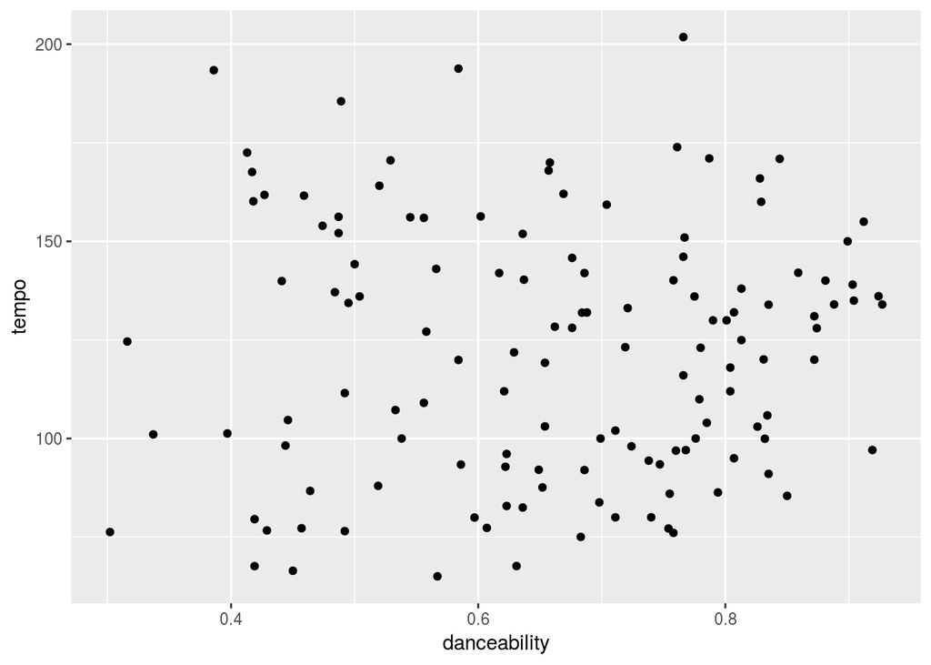

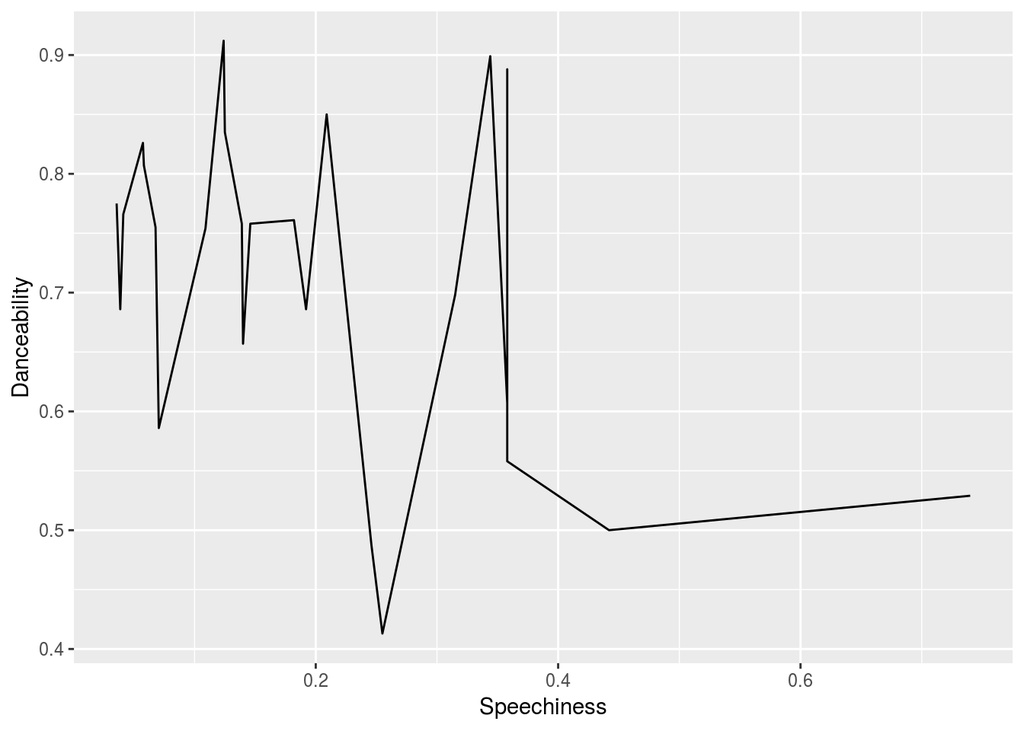

## Plots 2

So now, im gonna try to see if I can take each variable individually (speechiness, tempo and danceability) and plot it against the time of its release for Drake’s whole collection of songs, not just from his album Scorpion.

Starting off with danceability, a plot was created below.

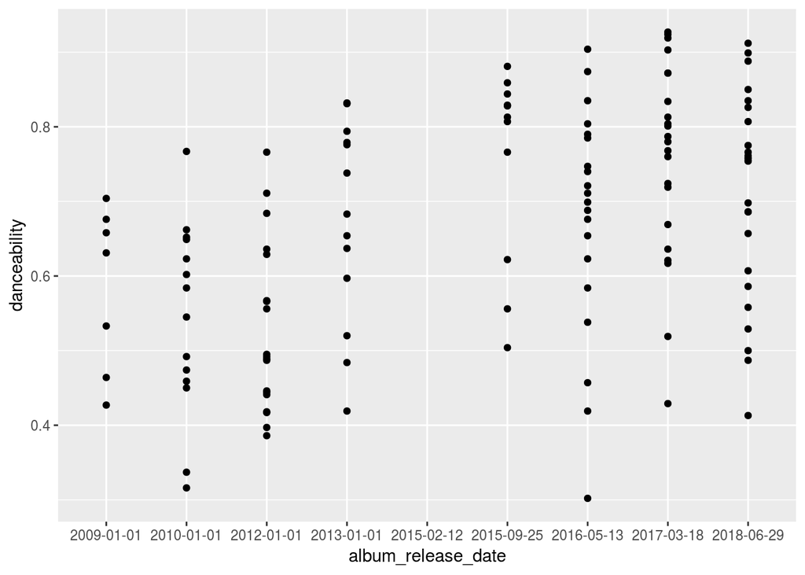

```r
drake_songs %>%
  ggplot(aes(x=album_release_date, y=danceability)) +
  geom_point()
```

Moving on to speechiness, a plot was generated below

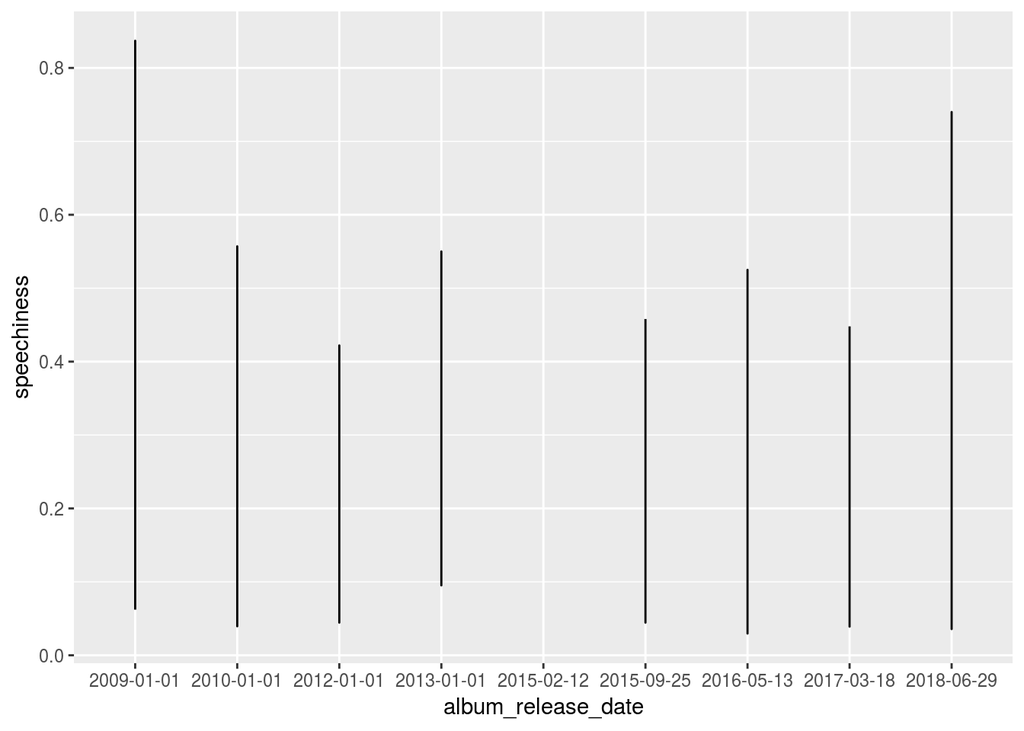

```r
drake_songs %>%
  ggplot(aes(x=album_release_date, y=speechiness)) +
  geom_line()
```

Lastly, I wanna see the role tempo has played in all of this.A plot was generated below.

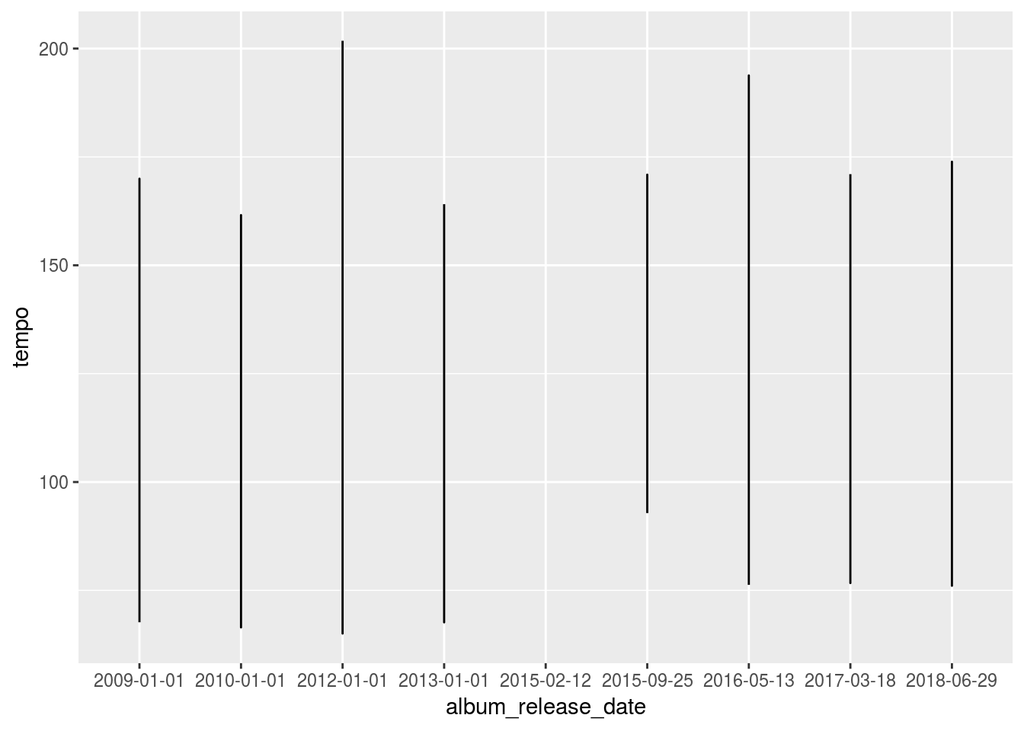

```r
drake_songs %>%
  ggplot(aes(x=album_release_date, y=tempo)) +
  geom_line()
```